# ggplot2 exercises

Mark Dunning and Matt Eldridge

Last modified: 12 Mar 2019

These exercises require you to generate plots of various kinds. Images of the plots that you should obtain are also shown.

## Part I – geoms and aesthetics

These first few exercises will run through some of the simple principles of creating a ggplot2 object, assigning aesthetics mappings and geoms.

1. Read in the cleaned patients dataset, `patient-data-cleaned.txt`.

### Scatterplots

2. Using the patient dataset generate a scatter plot of BMI versus Weight.

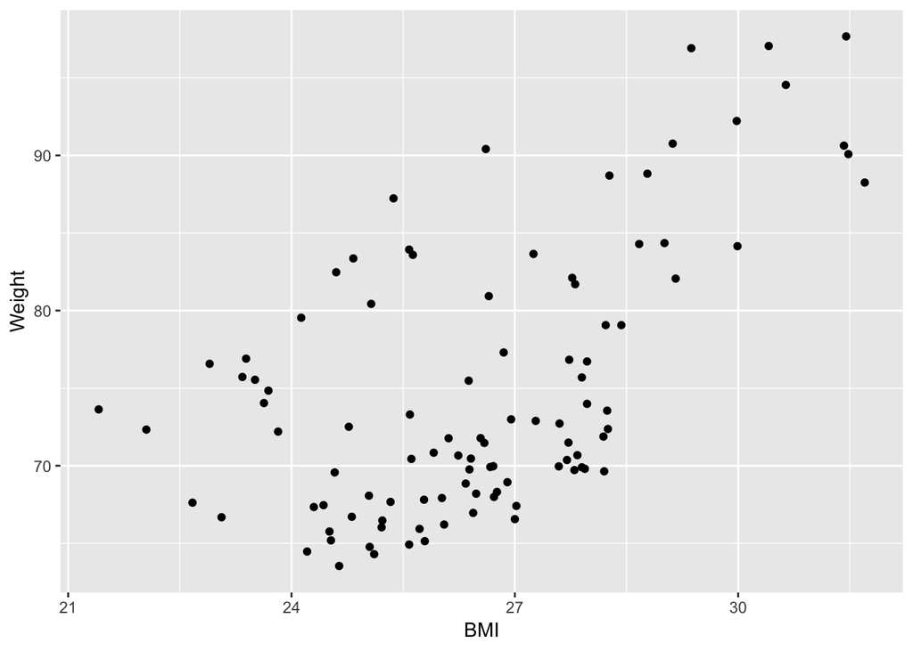

3. Extending the plot from exercise 2, add a colour scale to the scatterplot based on the Height variable.

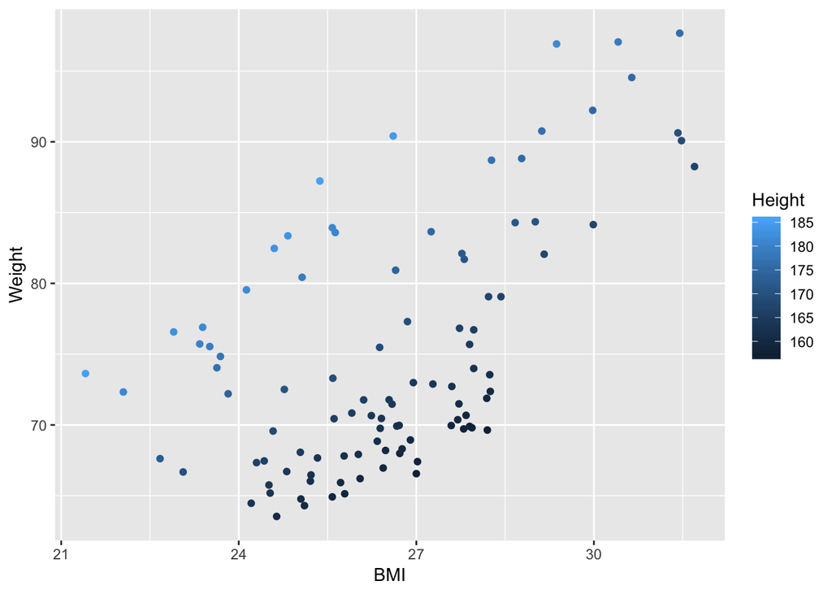

4. Following from exercise 3, split the BMI vs Weight plot into a grid of plots separated by Smoking status and Sex.

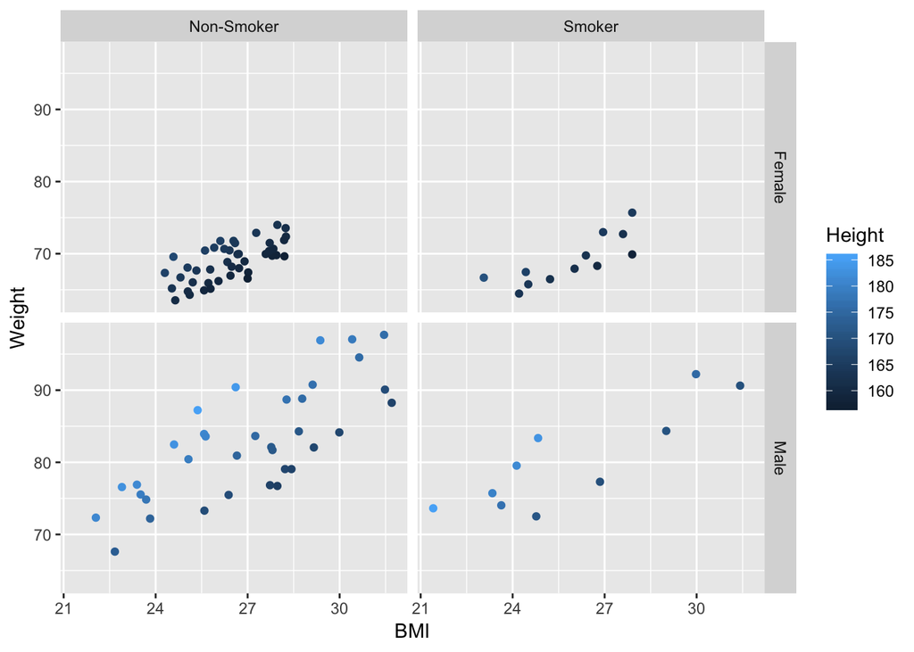

5. Using an additional geom, add an extra layer of a fit line to the solution from exercise 3.

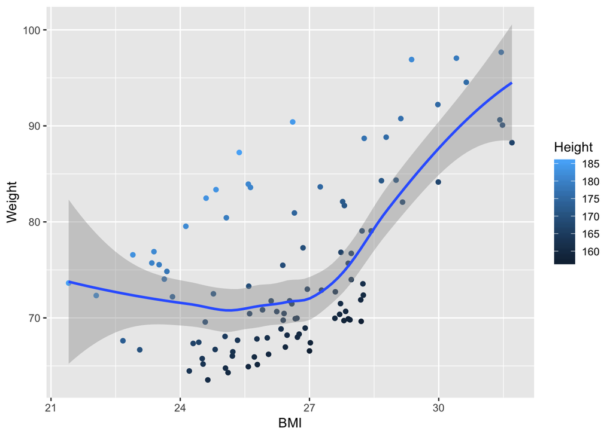

6. Does the fit in question 5 look good? Look at the help page for geom_smooth and adjust the method to fit a straight line without standard error bounds.

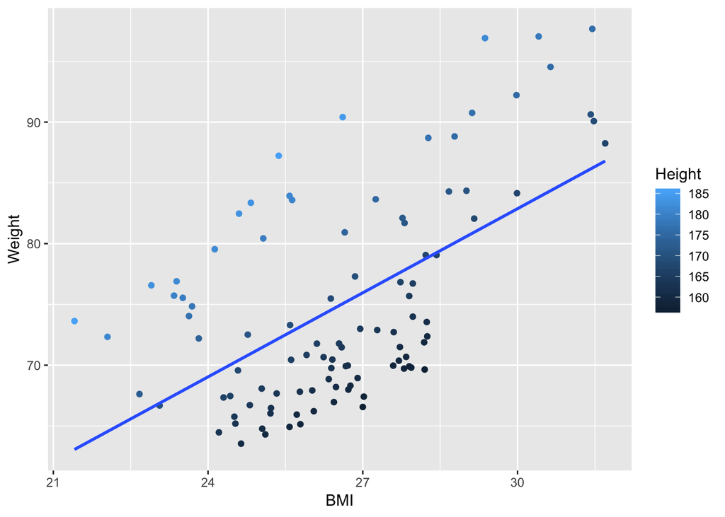

### Boxplots and Violin plots

7. Generate a boxplot of BMIs comparing smokers and non-smokers.

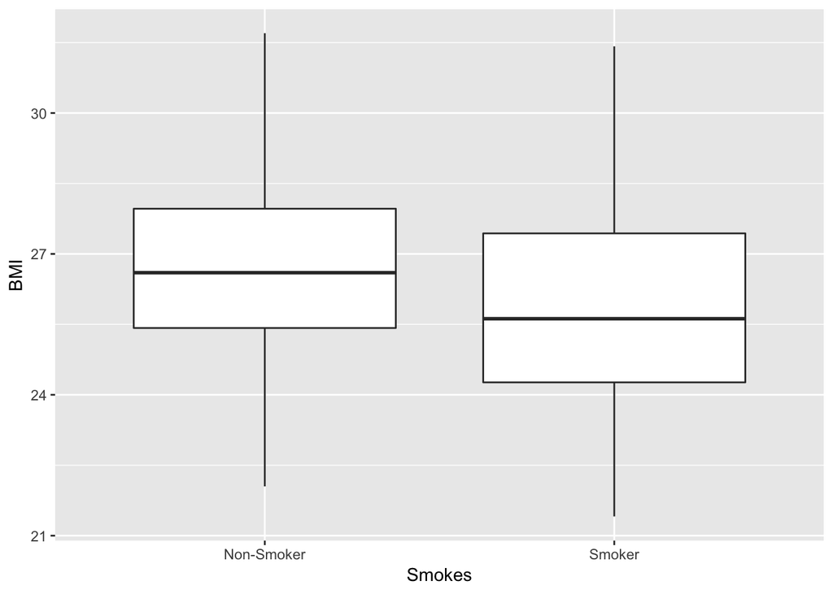

8. Following from the boxplot comparing smokers and non-smokers in exercise 7, colour boxplot edges by Sex.

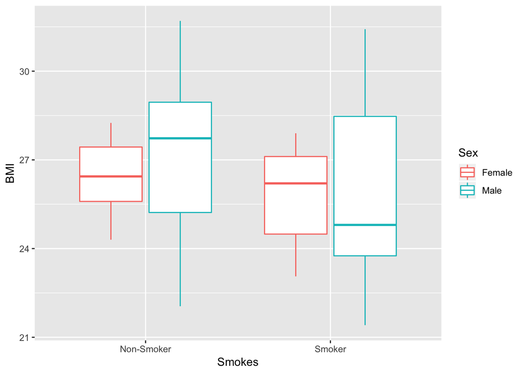

9. Now reproduce the boxplots in exercise 8 (grouped by smoker, coloured by sex) but now include a separate facet for people of different age (using Age column).

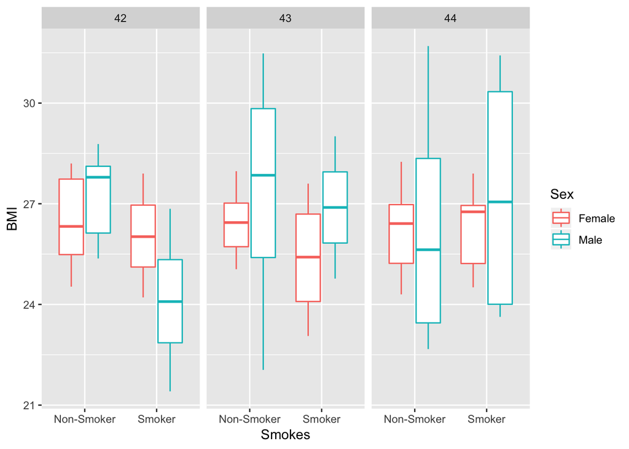

10. Produce a similar boxplot of BMIs but this time group data by Sex, colour by Age and facet by Smoking status.

*Hint: is Age currently the right type of variable for grouping in a box plot?*

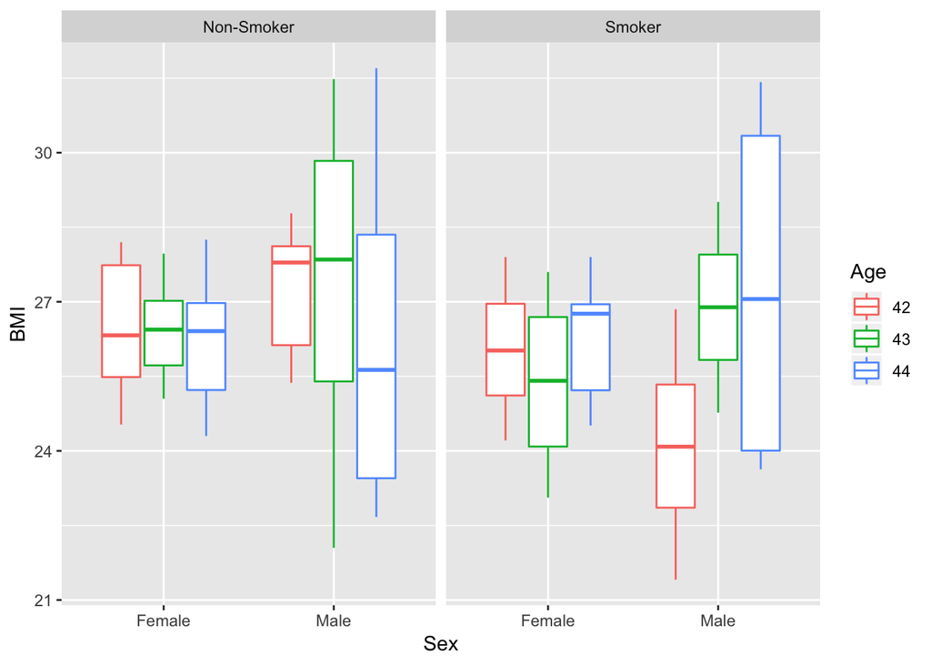

11. Regenerate the solution to exercise 10 but this time using a violin plot.

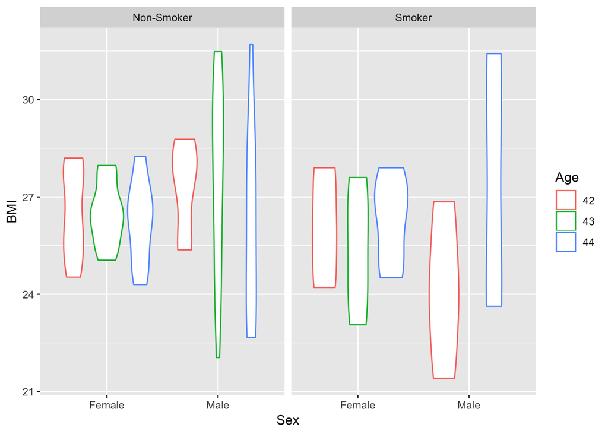

### Histogram and Density plots

12. Generate a histogram of BMIs with each bar coloured blue, choosing a suitable bin width.

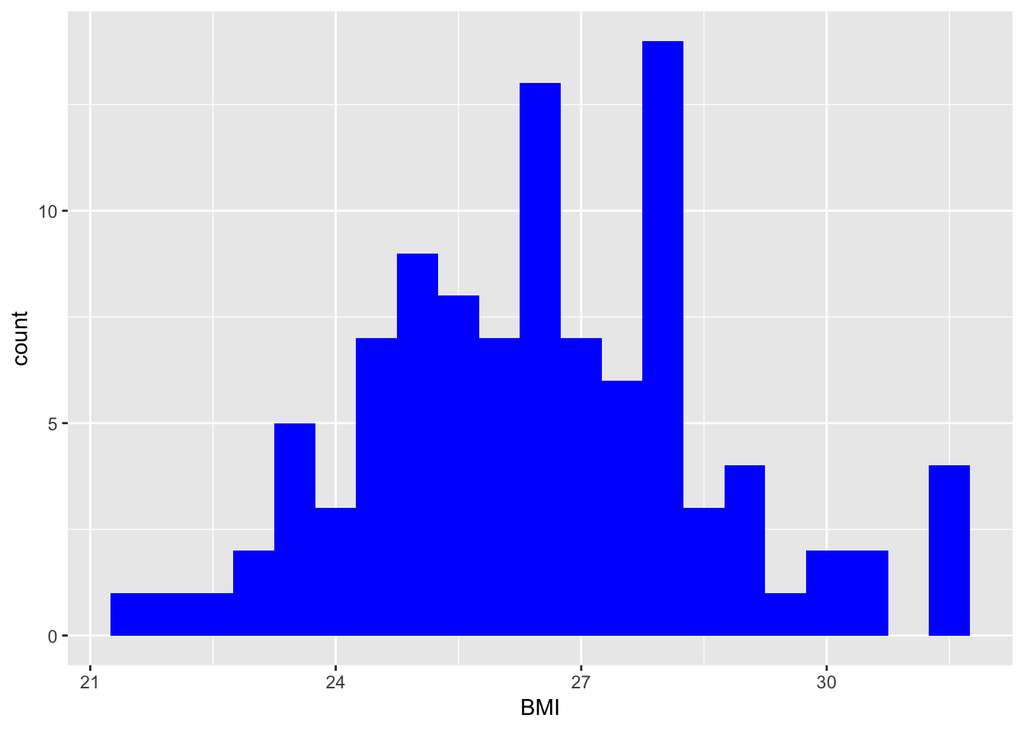

13. Generate density plots of BMIs coloured by Sex.

*Hint: alpha can be used to control transparancy.*

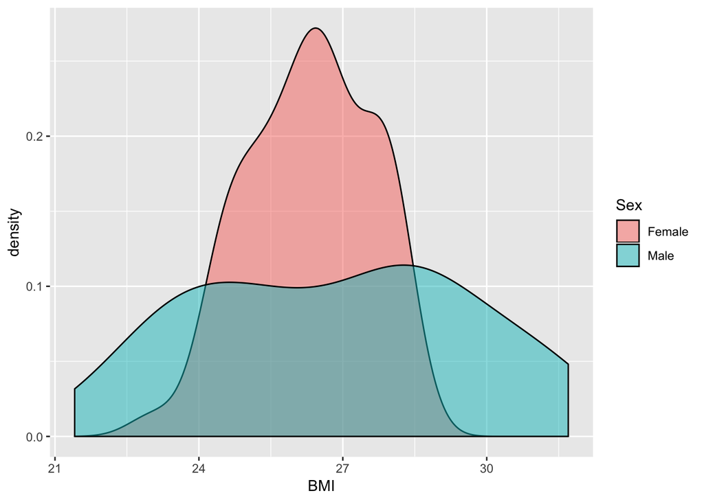

14. Generate a separate density plot of BMI coloured by sex for each Grade.

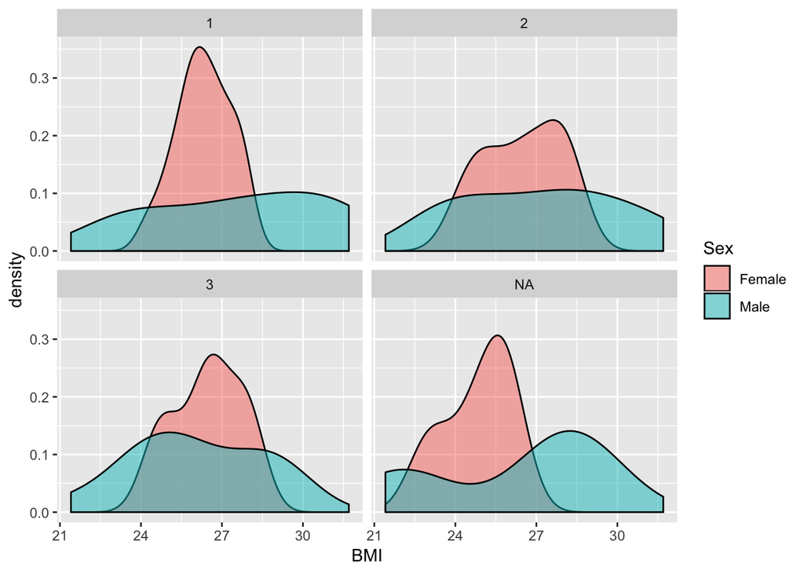

## Part II – scales, statistical transformations and themes

In these exercises we look at adjusting the scales and themes of our plots.

15. Read in the cleaned patients dataset, `patient-data-cleaned.txt`, and convert the Age variable to a factor.

### Scales

16. Generate a scatter plot of BMI versus Weight from the patients dataset.

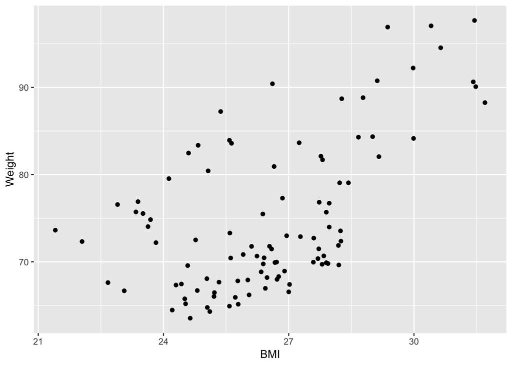

17. Starting from the previous plot, adjust the BMI axis to show only labels for 20, 30, 40 and the weight axis to show breaks for 60 to 100 in steps of 5, adding the units (kilograms) to the axis label.

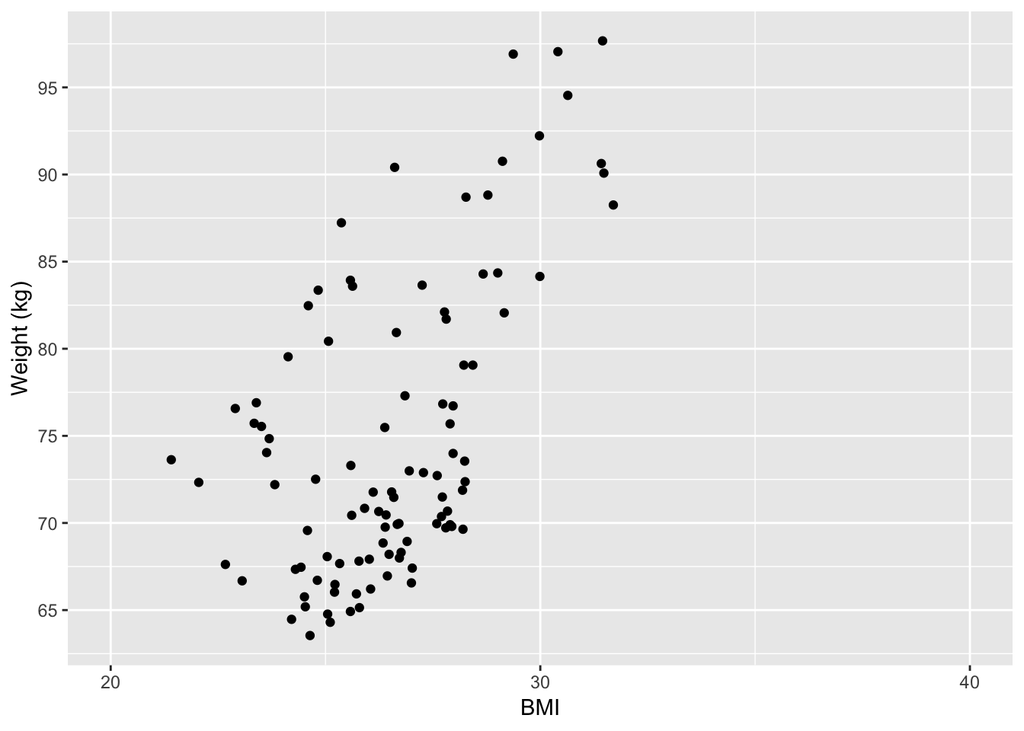

18. Create a violin plot of BMI by Age where violins are filled using a sequential colour palette.

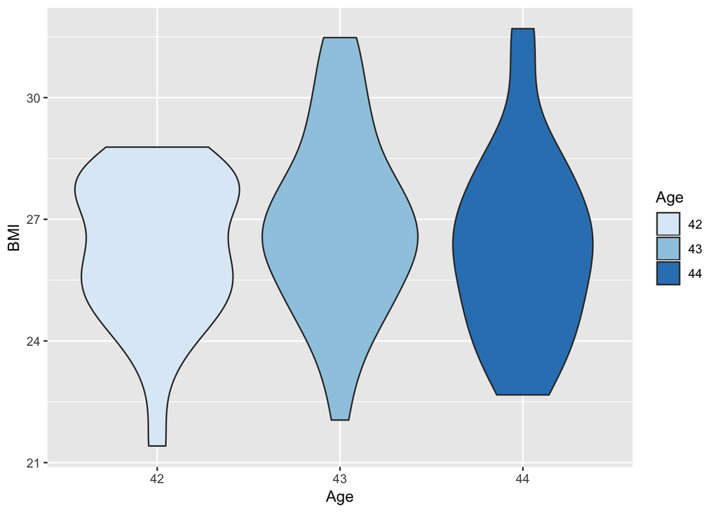

19. Create a scatterplot of BMI versus Weight and add a continuous colour scale for the height. Make the colour scale with a midpoint (set to mean point) colour of grey and extremes of green (low) and red (high).

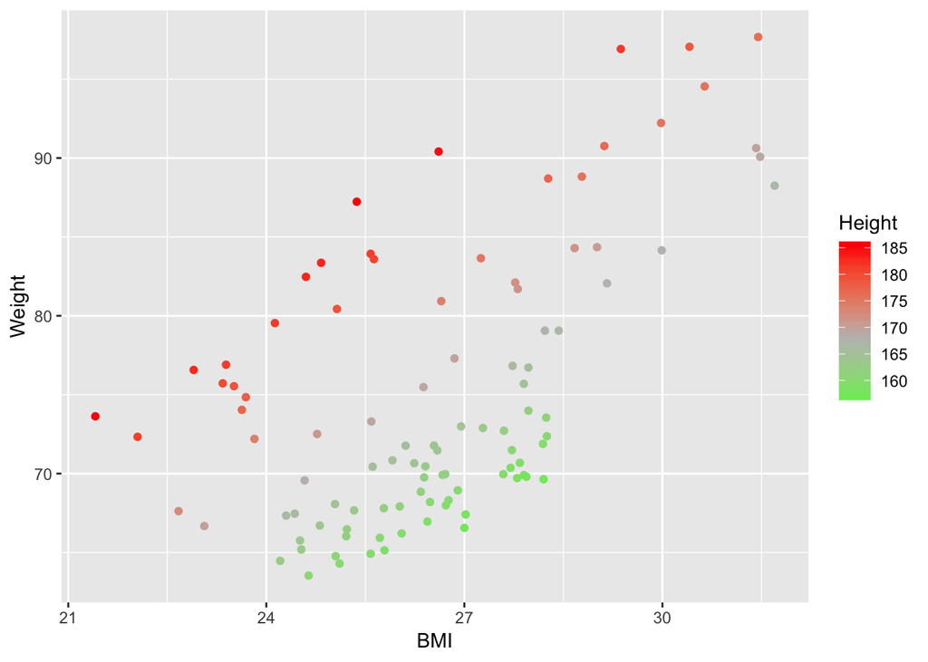

### Statistics

20. Recreate the scatterplot of BMI by weight this time colouring by age group and add a straight line fit (but no standard error/confidence intervals) for each age group.

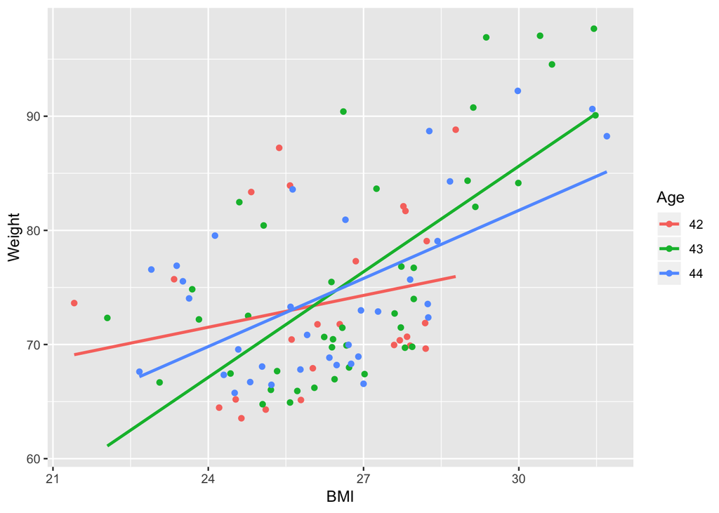

### Themes

21. Remove the legend title from the previous plot, change the background colours of legend keys to white and place the legend at the bottom of the plot.

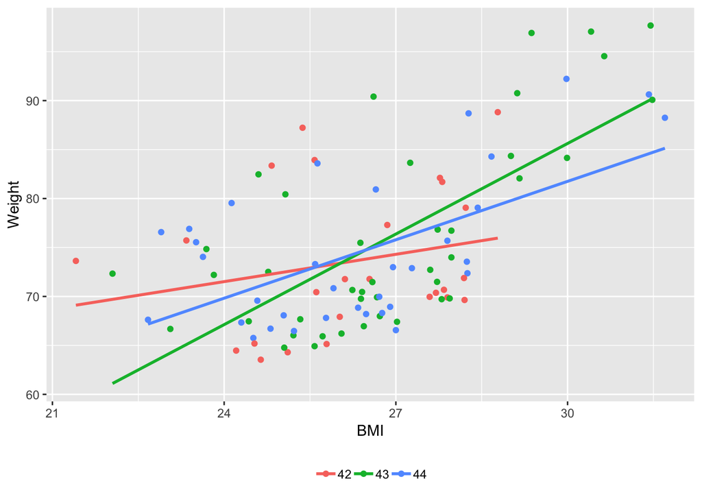

22. Add a title to the plot, remove minor grid lines and save the plot to a 7 by 7 inch image file.

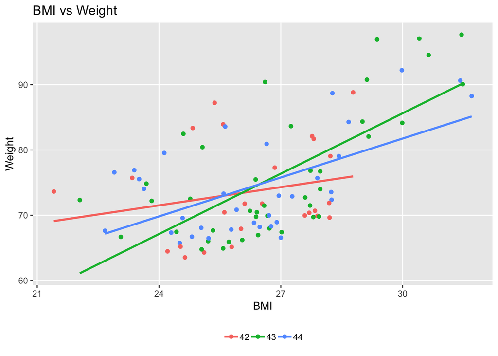